# Słodycze

Klaudia Grabowska i Gabriela Kuczyńska

# Wprowadzenie

Celem projektu jest eksploracja danych dotyczących najlepszych słodyczy.

## Obróbka danych

Dane wczytano bezpośrednio z pakietu fivethirtyeight.

```r
candy <- candy_rankings
```

Składają się z 85 rekordów i 13 zmiennych.

## Wykorzystane zmienne

W dalszej analizie wykorzystano następujące zmienne:

| Zmienna | Opis |
| --- | --- |
| *chocolate* | Czy zawiera czekoladę? (0 - nie, 1 - tak) |
| *fruity* | Czy ma owocowy smak? (0 - nie, 1 - tak) |
| *caramel* | Czy zawiera karmel? (0 - nie, 1 - tak) |
| *peanutalmondy* | Czy zawiera orzechy? (0 - nie, 1 - tak) |
| *nougat* | Czy zawiera nugat? (0 - nie, 1 - tak) |
| *crispedricewafer* | Czy jest chrupiące? (0 - nie, 1 - tak) |
| *pluribus* | Czy to jeden z wielu słodyczy w torbie lub pudełku? (0 - nie, 1 - tak) |
| *bar* | Czy to batonik? (0 - nie, 1 - tak) |
| *competitorname* | Nazwa słodycza |
| *sugarpercent* | Procentowa zawartość cukru |
| *pricepercent* | Procent ceny jednostkowej w porównaniu do reszty |
| *winpercent* | Całkowity procent wygranych po 269.000 parowaniach |
| *hard* | Czy jest twardy? (0 - nie, 1 - tak) |

Statystyki podsumowujące wybrane zmienne przedstawiają się następująco:

```r
# zamiana niektórych zmiennych na faktory
candy$chocolate <- factor(candy$chocolate, levels = c("TRUE","FALSE"), labels= c(1,0))
candy$fruity <- factor(candy$fruity, levels = c("TRUE","FALSE"), labels= c(1,0))
candy$caramel <-factor(candy$caramel, levels = c("TRUE","FALSE"), labels= c(1,0))
candy$peanutyalmondy <-factor(candy$peanutyalmondy, levels = c("TRUE","FALSE"), labels= c(1,0))
candy$nougat <-factor(candy$nougat, levels = c("TRUE","FALSE"), labels= c(1,0))
candy$peanutyalmondy <-factor(candy$peanutyalmondy, levels = c("TRUE","FALSE"), labels= c(1,0))
candy$crispedricewafer <- factor(candy$crispedricewafer, levels = c("TRUE","FALSE"), labels= c(1,0))
candy$hard <-factor(candy$hard, levels = c("TRUE","FALSE"), labels= c(1,0))
candy$bar <-factor(candy$bar, levels = c("TRUE","FALSE"), labels= c(1,0))
candy$pluribus <-factor(candy$pluribus, levels = c("TRUE","FALSE"), labels= c(1,0))
candy$competitorname <- factor(candy$competitorname)
candy_rankingsnew <- candy_rankings %>%
  pivot_longer(-c(competitorname, sugarpercent, pricepercent, winpercent,bar,hard,pluribus),
               names_to = "element", values_to = "contain") %>%
  mutate(contain = as.logical(contain)) %>%
  arrange(element)

candy_rankingspak <- candy_rankings %>%
  pivot_longer(-c(competitorname, sugarpercent, pricepercent, winpercent,chocolate, fruity, caramel, peanutyalmondy, nougat, crispedricewafer, hard),
               names_to = "opakowanie", values_to = "tak.nie") %>%
  mutate(tak.nie = as.logical(tak.nie)) %>%
  arrange(opakowanie)

knitr::kable(candy_rankingsnew %>%
  filter(contain=="TRUE") %>%
  group_by(element) %>%
  summarise(ilość=n()) %>%
  select(element, ilość))
```

| element | ilość |
| --- | --- |
| caramel | 14 |
| chocolate | 37 |
| crispedricewafer | 7 |
| fruity | 38 |
| nougat | 7 |
| peanutyalmondy | 14 |

Z powyższej tabeli można odczytać m.in., że słodycze najczęściej mają owocowy smak lub zawieraja czekoladę.Natomiast nugat, ryż preparowany itp. są rzadko używane.

Zmienne, które nie zostały tutaj uwzględnione, będą podsumowane w dalszej części analizy.

# Analiza

Przeprowadzona analiza obejmowała następujące zagadnienia:

- analizę procentowej zawartości cukru w słodyczach dla czekolady i dla karmelu
- analizę ceny w zależności od użytego składnika i opakowania
- analizę procentowej ilości zwycięstw w zależności od składu, opakowania, twardości słodyczy

## Analiza procentowej zawartości cukru

### Czekolada

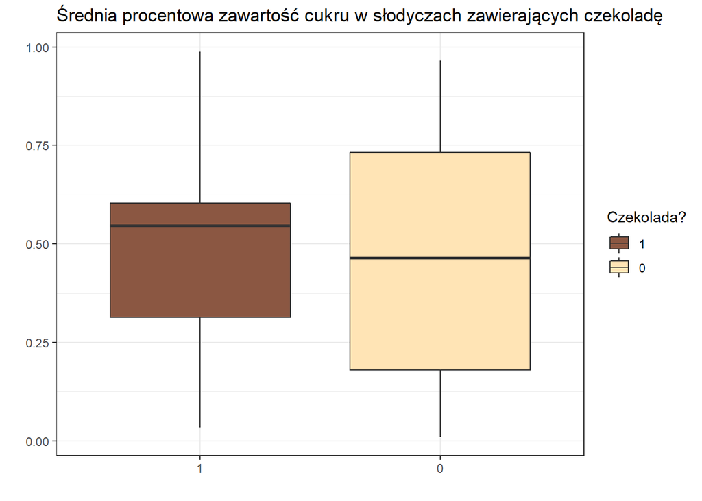

```r
candy %>%
  group_by(chocolate) %>%
  ggplot(aes(chocolate,sugarpercent, fill=chocolate))+
  geom_boxplot()+
  scale_fill_manual(values = c("lightsalmon4", "moccasin"), name= "Czekolada?")+
  ggtitle("Średnia procentowa zawartość cukru w słodyczach zawierających czekoladę")+
  ylab("")+
  xlab("") + theme_bw()
```

```r
#### Hipoteza badawcza: Średnia wartość zmiennej sugarpercent nie zależy od tego czy słodycz zawiera czekoladę czy nie.
#H0: wartość średnia zmiennej sugarpercent, jeśli słodycz nie zawiera czekolady jest równa wartości średniej sugarpercent jeśli czekolada jest oznaczona liczbą 0.
#H1: wartość średnia zmiennej sugarpercent, jeśli słodycz nie zawiera czekolady nie jest równa wartości średniej sugarpercent jeśli czekolada jest oznaczona liczbą 0.

#### średnia zawartość cukru w słodyczach niezawierających czekoladę
candy.choco0 <- candy$sugarpercent[candy$chocolate==0]
#### średnia zawartość cukru w słodyczach zawierających czekoladę
candy.choco1 <- candy$sugarpercent[candy$chocolate==1]
t.test(candy.choco0,candy.choco1)
```

```
##
##  Welch Two Sample t-test
##
## data:  candy.choco0 and candy.choco1
## t = -0.98564, df = 82.99, p-value = 0.3272
## alternative hypothesis: true difference in means is not equal to 0
## 95 percent confidence interval:
##  -0.17824735  0.06012235
## sample estimates:
## mean of x mean of y
## 0.4529375 0.5120000
```

```r
# test t wykazał że satystyka t= 0.98564 df(stopnie swobody)=82.99
# p-value = 0.3272 > 0,05 - nie ma podstaw do odrzucenia hipotezy H0
#nie ma istotnej różnicy w tych średnich
```

Test oraz wykres wykazały, że zawartość czekolady w słodyczach nie wpływa znacząco na średnią zawartość cukru w produktach.

### Karmel

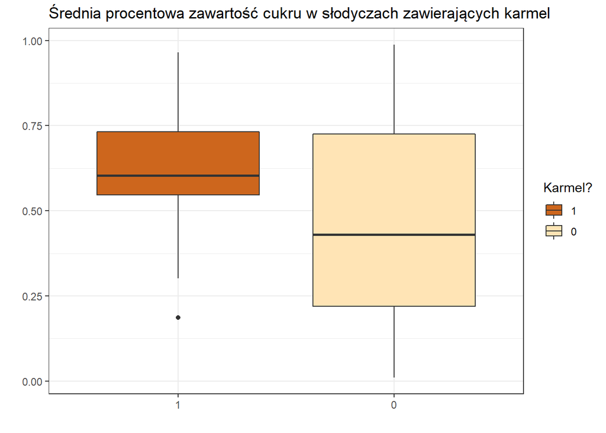

```r
candy %>%
  group_by(caramel) %>%
  ggplot(aes(caramel,sugarpercent, fill=caramel))+
  geom_boxplot()+
  scale_fill_manual(values = c("chocolate3", "moccasin"), name= "Karmel?")+
  ggtitle("Średnia procentowa zawartość cukru w słodyczach zawierających karmel")+
  ylab("")+
  xlab("") + theme_bw()
```

```r
#### Hipoteza badawcza: Średnia wartość zmiennej sugarpercent nie zależy od tego czy słodycz zawiera karmel czy nie.
#H0: wartość średnia zmiennej sugarpercent, jeśli słodycz nie zawiera karmelu jest równa wartości średniej sugarpercent jeśli karmel jest oznaczony liczbą 0.
#H1: wartość średnia zmiennej sugarpercent, jeśli słodycz nie zawiera karmelu nie jest równa wartości średniej sugarpercent jeśli karmel jest oznaczony liczbą 0.

#### średnia zawartość cukru w słodyczach niezawierających karmelu
candy.caramel0 <- candy$sugarpercent[candy$caramel==0]
#### średnia zawartość cukru w słodyczach zawierających karmelu
candy.caramel1 <- candy$sugarpercent[candy$caramel==1]
t.test(candy.caramel0,candy.caramel1)
```

```
##
##  Welch Two Sample t-test
##
## data:  candy.caramel0 and candy.caramel1
## t = -2.4292, df = 22.108, p-value = 0.02371
## alternative hypothesis: true difference in means is not equal to 0
## 95 percent confidence interval:
##  -0.31175571 -0.02464266
## sample estimates:
## mean of x mean of y
## 0.4509437 0.6191428
```

```r
# test t wykazał że satystyka t= 2.4292 df(stopnie swobody)=22.108
# p-value = 0.02371 < 0,05 - należy odrzucić H0 i przyjąć H1
#(jest istotna roznica w tych średnich)
```

Z kolei w przypadku karmelu widzimy, że ma on już większy wpływ na zawartość cukru w słodyczach.

## Analiza ceny

### Składnik

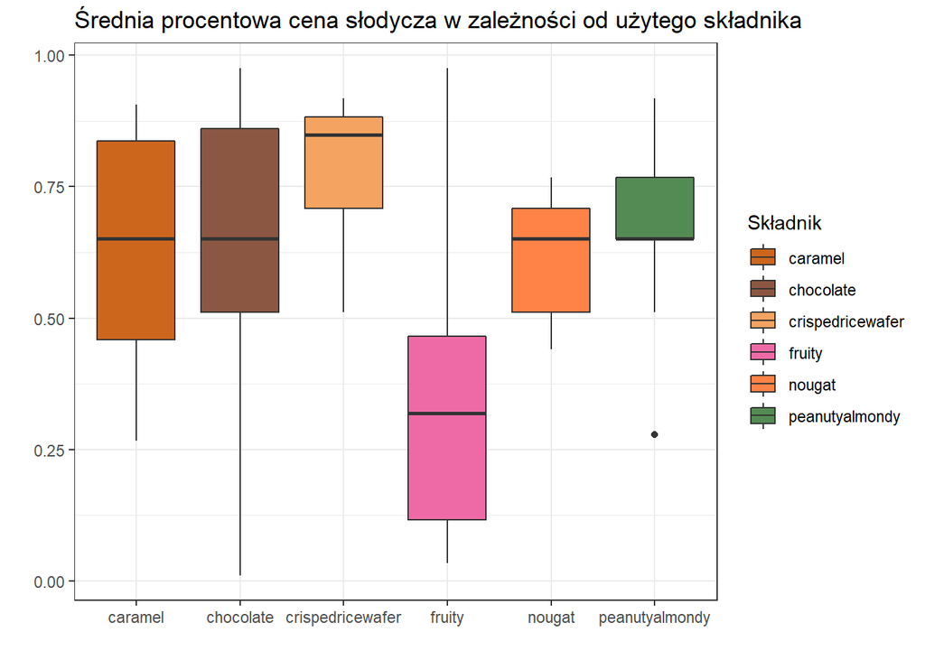

```r
candy_rankingsnew %>%
  filter(contain=="TRUE") %>%
  group_by(element) %>%
  select(element,pricepercent) %>%
  ggplot(aes(element,pricepercent, fill=element))+
  geom_boxplot()+
  scale_fill_manual(values = c("chocolate3", "lightsalmon4","sandybrown","hotpink2","sienna1","palegreen4"), name= "Składnik")+
  ylab("")+xlab("")+
  ggtitle("Średnia procentowa cena słodycza w zależności od użytego składnika")+ theme_bw()
```

```r
#H0: wartości średnie zmiennej pricepercent, w grupach wyznaczonych przez kategorie zmiennej element są wszystkie równe.
#H1: wartości średnie zmiennej pricepercent, w grupach wyznaczonych przez kategorie zmiennej element istnieją przynajmniej dwie kategorie, w których średnie są różne.

price.aov<- aov(candy_rankingsnew$pricepercent[candy_rankingsnew$contain=="TRUE"] ~ candy_rankingsnew$element[candy_rankingsnew$contain=="TRUE"])
summary(price.aov)
```

```
##                                                                 Df Sum Sq
## candy_rankingsnew$element[candy_rankingsnew$contain == "TRUE"]   5  2.725
## Residuals                                                      111  5.598
##                                                                Mean Sq F value
## candy_rankingsnew$element[candy_rankingsnew$contain == "TRUE"]  0.5451   10.81
## Residuals                                                       0.0504
##                                                                  Pr(>F)
## candy_rankingsnew$element[candy_rankingsnew$contain == "TRUE"] 1.75e-08 ***
## Residuals
## ---
## Signif. codes:  0 '***' 0.001 '**' 0.01 '*' 0.05 '.' 0.1 ' ' 1
```

```r
# test t wykazał że satystyka F= 10.81, df(dla międzygrup.)=5, df(dla wewnątrgrup.)=111
# p-value = 1.75e-08 < 0,05 - należy odrzucić H0 i przyjąć H1
#istnieją co najmniej dwie grupy, w których średnia się różni
```

Możemy zauważyć, że słodycze zawierające ryż preperowany, wafle itp. są najdroższe. Co jest zaskakujące, ponieważ orzechy są zdecydowanie droższym produktem , a mimo to słodycze, które je zawierają są tańsze. Najtańsze okazały się słodycze o owocowym smaku. Cena produktów zawierających karmel, czekoladę i nugat jest porównywalna.

### Sposób pakowania

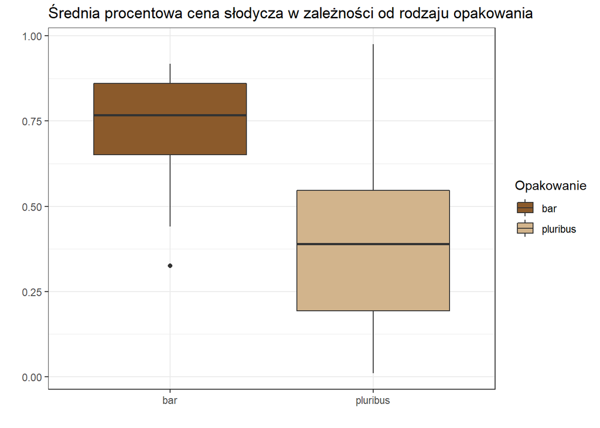

```r
candy_rankingspak %>%
  filter(tak.nie=="TRUE") %>%
  group_by(opakowanie) %>%
  select(opakowanie,pricepercent) %>%
  ggplot(aes(opakowanie,pricepercent, fill=opakowanie))+
  geom_boxplot()+
  scale_fill_manual(values = c("tan4", "tan"), name= "Opakowanie")+
  ylab("")+xlab("")+
  ggtitle("Średnia procentowa cena słodycza w zależności od rodzaju opakowania")+
  theme_bw()
```

```r
#### Hipoteza badawcza: Średnia wartość zmiennej pricepercent w zależności od opakowania.
#H0: mean(x)=mu
#H1: mean(x)=/mu

#### średnia procentowa cena w słodyczach w opakowaniu bar
candy.bar <- candy_rankingspak$pricepercent[candy_rankingspak$opakowanie=="bar"&candy_rankingspak$tak.nie=="TRUE"]
#### średnia procentowa cena w słodyczach w opakowaniu pluribus
candy.plur <- candy_rankingspak$pricepercent[candy_rankingspak$opakowanie=="pluribus"&candy_rankingspak$tak.nie=="TRUE"]
t.test(candy.bar,candy.plur)
```

```
##
##  Welch Two Sample t-test
##
## data:  candy.bar and candy.plur
## t = 5.5968, df = 56.675, p-value = 6.609e-07
## alternative hypothesis: true difference in means is not equal to 0
## 95 percent confidence interval:
##  0.2039607 0.4312623
## sample estimates:
## mean of x mean of y
## 0.7259524 0.4083409
```

```r
# test t wykazał że satystyka t= 5.5968 df(stopnie swobody)=56.675
# p-value = 6.609e-07 < 0,05 - należy odrzucić H0 i przyjąć H1
# średnie istotnie się różnią
```

Zdecydowanie droższe okazały się słodycze w batoniku. Za słodycze w paczkach czy pudełkach (czyli takie, które są pakowane po większej ilości sztuk) średnio zapłacimy mniej.

## Analiza zwycięstw

### Ranking

```r
knitr::kable(candy_rankings %>%
  select(competitorname, winpercent) %>%
  arrange(desc(winpercent)) %>%
  head(10))
```

| competitorname | winpercent |
| --- | --- |
| Reese’s Peanut Butter cup | 84.18029 |
| Reese’s Miniatures | 81.86626 |
| Twix | 81.64291 |
| Kit Kat | 76.76860 |
| Snickers | 76.67378 |
| Reese’s pieces | 73.43499 |
| Milky Way | 73.09956 |
| Reese’s stuffed with pieces | 72.88790 |
| Peanut butter M&M’s | 71.46505 |
| Nestle Butterfinger | 70.73564 |

### Pozycja w rankingu a skład

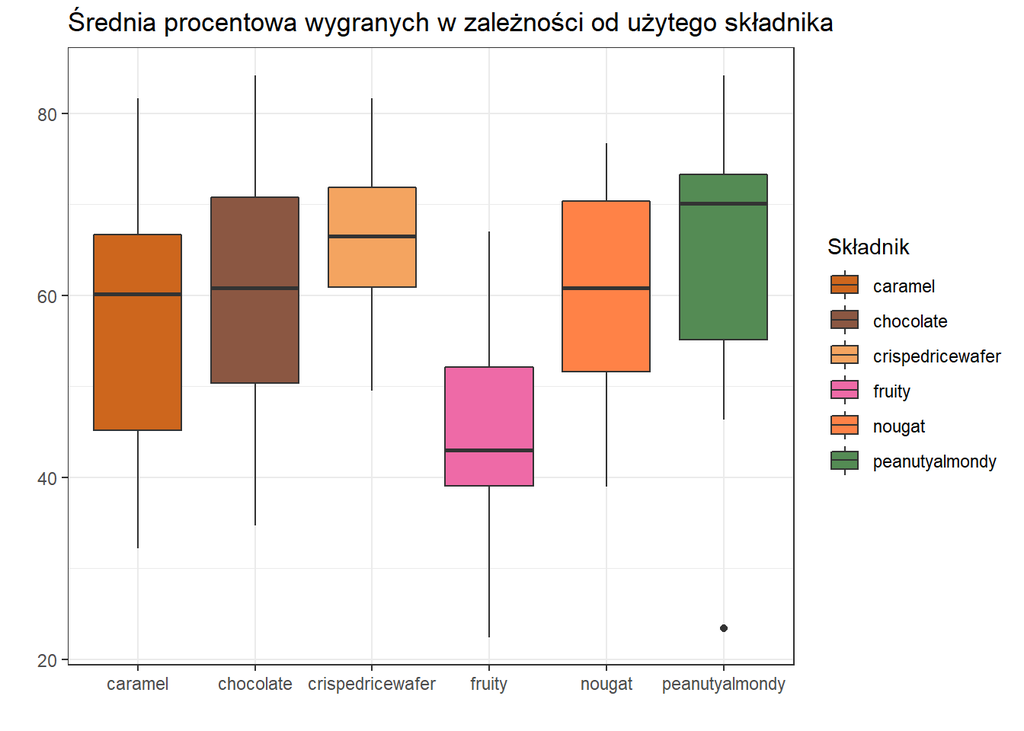

```r
candy_rankingsnew %>%
  filter(contain=="TRUE") %>%
  group_by(element) %>%
  select(element,winpercent) %>%
  ggplot(aes(element,winpercent, fill=element))+
  geom_boxplot()+
  scale_fill_manual(values = c("chocolate3", "lightsalmon4","sandybrown","hotpink2","sienna1","palegreen4"), name= "Składnik")+
  ylab("")+xlab("")+
  ggtitle("Średnia procentowa wygranych w zależności od użytego składnika")+
  theme_bw()
```

```r
#H0: wartości średnie zmiennej winpercent, w grupach wyznaczonych przez kategorie zmiennej element są wszystkie równe.
#H1: wartości średnie zmiennej winpercent, w grupach wyznaczonych przez kategorie zmiennej opakowanie istnieją przynajmniej dwie kategorie, w których średnie są różne.

winel.aov <- aov(candy_rankingsnew$winpercent[candy_rankingsnew$contain=="TRUE"] ~ candy_rankingsnew$element[candy_rankingsnew$contain=="TRUE"])
summary(winel.aov)
```

```
##                                                                 Df Sum Sq
## candy_rankingsnew$element[candy_rankingsnew$contain == "TRUE"]   5   7937
## Residuals                                                      111  18542
##                                                                Mean Sq F value
## candy_rankingsnew$element[candy_rankingsnew$contain == "TRUE"]    1588   9.503
## Residuals                                                          167
##                                                                  Pr(>F)
## candy_rankingsnew$element[candy_rankingsnew$contain == "TRUE"] 1.45e-07 ***
## Residuals
## ---
## Signif. codes:  0 '***' 0.001 '**' 0.01 '*' 0.05 '.' 0.1 ' ' 1
```

```r
TukeyHSD(winel.aov)
```

```
##   Tukey multiple comparisons of means
##     95% family-wise confidence level
##
## Fit: aov(formula = candy_rankingsnew$winpercent[candy_rankingsnew$contain == "TRUE"] ~ candy_rankingsnew$element[candy_rankingsnew$contain == "TRUE"])
##
## $`candy_rankingsnew$element[candy_rankingsnew$contain == "TRUE"]`
##                                       diff         lwr       upr     p adj
## chocolate-caramel                 3.574622  -8.1865997 15.335843 0.9502205
## crispedricewafer-caramel          8.823344  -8.5278282 26.174517 0.6809589
## fruity-caramel                  -13.227166 -24.9458295 -1.508503 0.0173485
## nougat-caramel                    2.704972 -14.6462008 20.056144 0.9975687
## peanutyalmondy-caramel            6.350229  -7.8169440 20.517402 0.7845036
## crispedricewafer-chocolate        5.248723 -10.2005727 20.698018 0.9217468
## fruity-chocolate                -16.801788 -25.4588433 -8.144733 0.0000020
## nougat-chocolate                 -0.869650 -16.3189453 14.579645 0.9999835
## peanutyalmondy-chocolate          2.775607  -8.9856141 14.536829 0.9833470
## fruity-crispedricewafer         -22.050511 -37.4674319 -6.633589 0.0009141
## nougat-crispedricewafer          -6.118373 -26.1537808 13.917036 0.9492305
## peanutyalmondy-crispedricewafer  -2.473115 -19.8242877 14.878057 0.9984166
## nougat-fruity                    15.932138   0.5152166 31.349059 0.0384761
## peanutyalmondy-fruity            19.577395   7.8587321 31.296059 0.0000599
## peanutyalmondy-nougat             3.645257 -13.7059152 20.996430 0.9901685
```

```r
# test t wykazał że satystyka F= 9.503, df(dla międzygrup.)=5, df(dla wewnątrgrup.)=111
# p-value = 1.45e-07 < 0,05 - należy odrzucić H0 i przyjąć H1
#istnieją co najmniej dwie grupy w których średnia się różni
```

Okazuje się że, najmniejszą popularnością cieszyły się słodycze o owocowym smaku. Reszta składników plasuje się na podobnym poziomie.

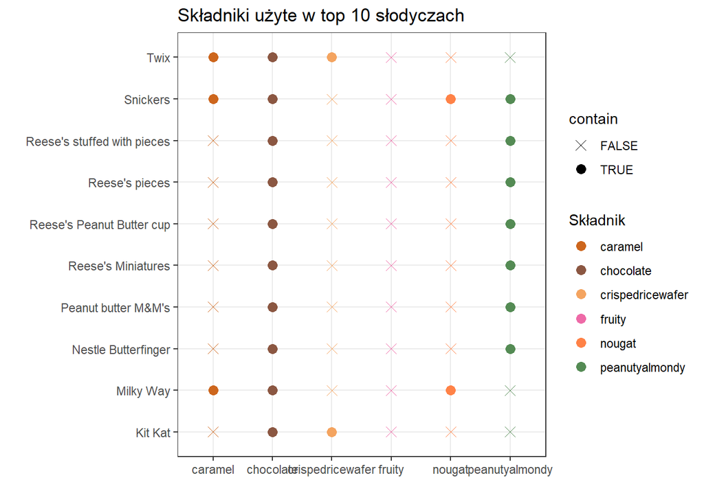

```r
candy_rankingsnew %>%
  filter(winpercent >= 70.73564) %>%
  group_by(element) %>%
  select(element,competitorname,contain) %>%
  ggplot(aes(element,competitorname,col=element, shape=contain))+
  geom_point(aes(col=element, shape=contain),size = 3)+
  ylab("")+xlab("")+
    ggtitle("Składniki użyte w top 10 słodyczach")+
  scale_shape_manual(values = c(4,16))+
  scale_color_manual(values = c("chocolate3", "lightsalmon4","sandybrown","hotpink2","sienna1","palegreen4"), name= "Składnik")+
 theme_bw()
```

Jak widać produkty, które znajdują się najwyżej w rankingu w większości zawierają składniki takie jak czekolada i orzechy, które znajdowały się wysoko w rankingu ogólnym. Żaden z topowych słodyczy nie ma owocowego smaku, który cieszył się najmniejszym powodzeniem i wygrał najmniej bitew.

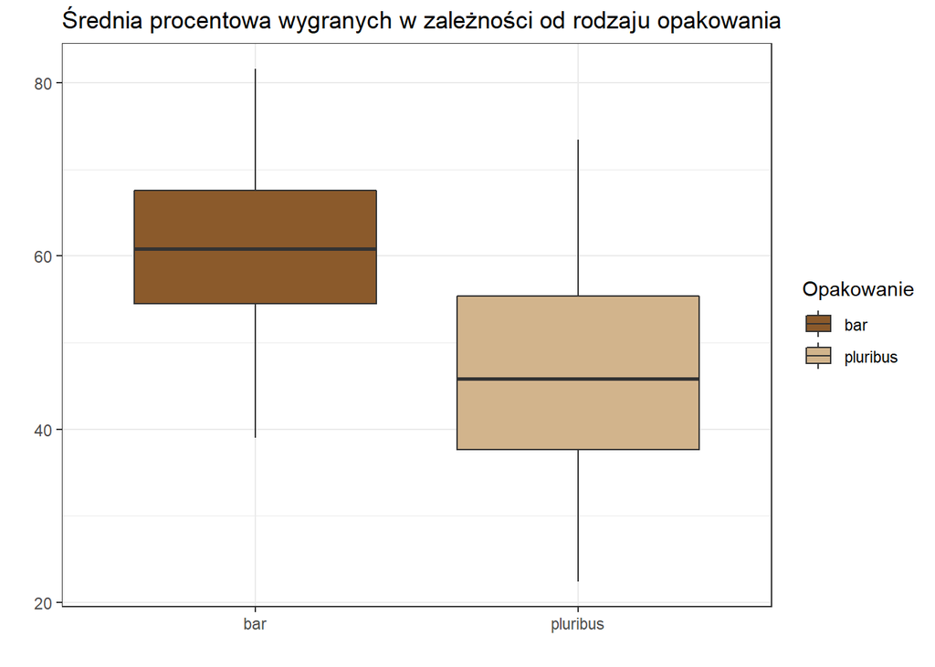

```r
candy_rankingspak %>%
  filter(tak.nie=="TRUE") %>%
  group_by(opakowanie) %>%
  select(opakowanie,winpercent) %>%
  ggplot(aes(opakowanie,winpercent, fill=opakowanie))+
  geom_boxplot()+
  scale_fill_manual(values = c("tan4", "tan"), name= "Opakowanie")+
  ylab("")+xlab("")+
  ggtitle("Średnia procentowa wygranych w zależności od rodzaju opakowania")+
  theme_bw()
```

```r
#### Hipoteza badawcza: Średnia wartość zmiennej pricepercent w zależności od opakowania.
#H0: mean(x)=mu
#H1: mean(x)=/mu

#### średnia procentowa cena w słodyczach w opakowaniu bar
win.bar <- candy_rankingspak$winpercent[candy_rankingspak$opakowanie=="bar"&candy_rankingspak$tak.nie=="TRUE"]
#### średnia procentowa cena w słodyczach w opakowaniu pluribus
win.plur <- candy_rankingspak$winpercent[candy_rankingspak$opakowanie=="pluribus"&candy_rankingspak$tak.nie=="TRUE"]
t.test(win.bar,win.plur)
```

```
##
##  Welch Two Sample t-test
##
## data:  win.bar and win.plur
## t = 4.5961, df = 46.369, p-value = 3.319e-05
## alternative hypothesis: true difference in means is not equal to 0
## 95 percent confidence interval:
##   8.135547 20.809717
## sample estimates:
## mean of x mean of y
##  61.29541  46.82278
```

```r
# test t wykazał że satystyka t= 4.5961 df(stopnie swobody)=46.369
# p-value = 3.319e-05 < 0,05 - należy odrzucić H0 i przyjąć H1
# średnie istotnie się różnią
```

Z wykresu wynika, że wskaźnik zwycięstw słodyczy w batoniku jest wyższy niżeli pojedynczy słodycz z opakowania.

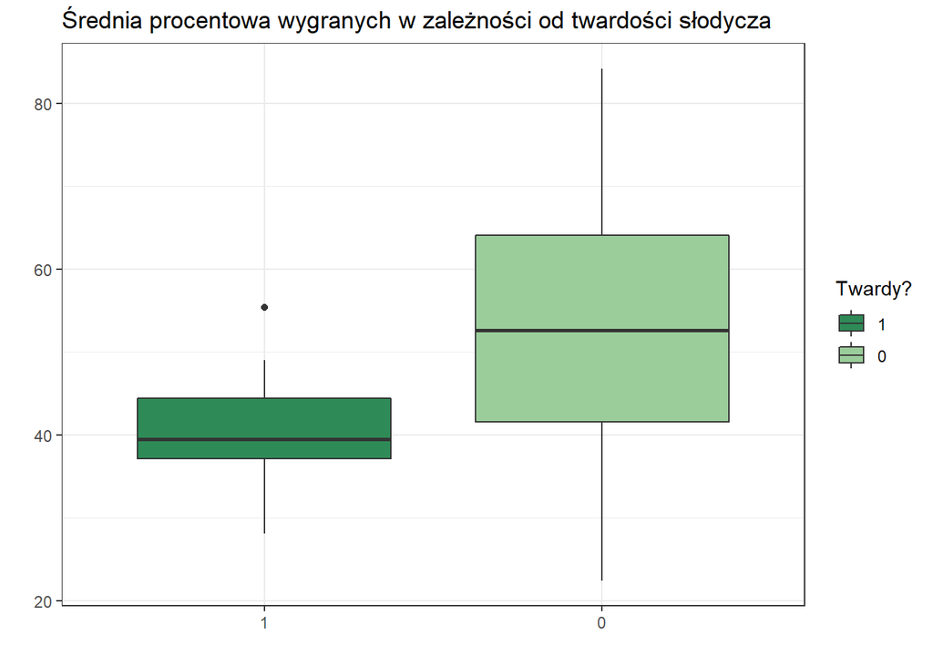

```r
candy %>%
  group_by(hard) %>%
  ggplot(aes(hard, winpercent, fill=hard))+
  geom_boxplot()+
   scale_fill_manual(values = c("seagreen", "darkseagreen3"), name= "Twardy?")+
  ylab("")+xlab("")+
  ggtitle("Średnia procentowa wygranych w zależności od twardości słodycza")+
  theme_bw()
```

```r
#### Hipoteza badawcza: Średnia wartość zmiennej winpercent nie zależy od tego czy słodycz jest twardy czy nie.
#H0: wartość średnia zmiennej winpercent, jeśli słodycz nie jest twardy jest równa wartości średniej winpercent jeśli twardość jest oznaczona liczbą 0.
#H1: wartość średnia zmiennej winpercent, jeśli słodycz nie jest twardy nie jest równa wartości średniej winpercent jeśli twardość jest oznaczona liczbą 0.

#### średnia procentowa ilość zwycięstw cukru w słodyczach nietwardych
candy.hard0 <- candy$winpercent[candy$hard==0]
#### średnia procentowa ilość zwycięstw w słodyczach twardych
candy.hard1 <- candy$winpercent[candy$hard==1]
t.test(candy.hard0,candy.hard1)
```

```
##
##  Welch Two Sample t-test
##
## data:  candy.hard0 and candy.hard1
## t = 4.6244, df = 45.444, p-value = 3.125e-05
## alternative hypothesis: true difference in means is not equal to 0
## 95 percent confidence interval:
##   6.72385 17.09505
## sample estimates:
## mean of x mean of y
##  52.41843  40.50898
```

```r
# test t wykazał że satystyka t= 4.6244 df(stopnie swobody)=45.444
# p-value =  3.125e-05 < 0,05 - odrzucamy hipotezę H0 i przyjmujemy H1
# średnie sie isttnie różnią
```

Możemy zauważyć, że słodycze, które są miękkie wygrały więcej sparowań.

# Wnioski

1. Analiza procentowej zawartości cukru w słodyczach wykazała że obecność czekolady w produkcie nie ma znaczącego wpływu na ilość cukru. Z kolei obecność karmelu wpływa znacząco na ilość cukru w słodyczu, co nie jest zaskoczeniem, ponieważ karmel w całości składa się z cukru.
2. Okazało się, że najtańszymi słodyczami są te, które miały owocowy smak - ciekawym jest też to, że są one najmniej popularnymi produktami i słodycze mające owocpwy smak wygrały najmniej bitew.
3. Najlepszą Top trójką są: Reese’s Peanut Butter cup, Reese’s Miniatures, Twix.
4. Większą popularnością cieszą się słodycze w batoniku aniżeli pakowane po wiele sztuk.
5. Zdecydowanym faworytem okazały się miękkie słodkości.

# Co dalej?

Dalsze analizy mogłyby uwzględnić:

- Kolejne próby zbadania czy dany składnik wpływa na zawartość cukru (u nas uwzględniony tylko: karmel, czekolada).
- Analizę czy procentowa zawartość cukru wpływa na procentową ilość zwycięstw.
- Analizę czy procentowa cena słodycza wpływa na procentową ilość zwycięstw.

### Źródła danych i wykorzystane pomoce:

*https://github.com/fivethirtyeight/data/tree/master/candy-power-ranking